# SLV Assignment 1: Exploratory Data Analysis

Shannon Dickson and Simranjit Kaur

October 03 2022

# Introduction

A research study in the US found that students with higher grades (mostly A’s) are less likely to drink alcohol and drink alcohol less frequently than students with lower grades (mostly D’s). In this study, 24% of students with mostly A’s currently drink alcohol compared to 52% of students with mostly D’s. Further, 11% of students with mostly A’s engage in binge-drinking behaviours compared to 34% of students with mostly D’s [(Youth Risk Behaviour Survey, 2015)](https://www.cdc.gov/healthyyouth/health_and_academics/pdf/DASHfactsheetAlcohol.pdf). Alcohol can lead to poor sleeping habits, mental health issues and reduced concentration, in turn affecting academic achievement. Our research question is primarily concerned with the effect (if any) of alcohol on grades in mathematics in two Portuguese high schools. Students responded to a questionnaire about their social-demographic status, alcohol use, family and personal relationships, and attitudes towards studying. Information about the student’s grades across the academic year were collated from school reports. Our secondary research question explores if there are *other* circumstantial factors that influence grades. Alcohol consumption is measured during weekdays (**Dalc**) and weekends (**Walc**) on a scale from 1 (very low) to 5 (very high). Since binge-drinking is common in students with lower grades, we will focus on weekend alcohol consumption. Grades are assessed in the first and second academic period with the final grade being the average of the two. We will focus both on the pattern of grades across the year as well as the final grade only.

# Descriptive statistics

Table 1: Student characteristics

| Variable | Overall, N = 395 | School GP, N = 349 | School MS, N = 46 | p-value |
| --- | --- | --- | --- | --- |
| Gender |  |  |  | 0.8 |
| Female | 208 (53%) | 183 (52%) | 25 (54%) |  |
| Male | 187 (47%) | 166 (48%) | 21 (46%) |  |
| Internet at home |  |  |  | 0.008 |
| Access | 329 (83%) | 297 (85%) | 32 (70%) |  |
| No access | 66 (17%) | 52 (15%) | 14 (30%) |  |
| Age | 16.70 (1.28) | 16.52 (1.22) | 18.02 (0.88) | <0.001 |
| Quality of family relationships | 3.94 (0.90) | 3.96 (0.87) | 3.83 (1.06) | 0.4 |
| Mother’s education | 2.75 (1.09) | 2.80 (1.07) | 2.35 (1.22) | 0.019 |
| Father’s education | 2.52 (1.09) | 2.55 (1.08) | 2.28 (1.13) | 0.13 |
| Hours of study | 2.04 (0.84) | 2.06 (0.85) | 1.83 (0.71) | 0.042 |
| Weekend alcohol consumption | 2.29 (1.29) | 2.26 (1.31) | 2.52 (1.11) | 0.15 |
| Weekday alcohol consumption | 1.48 (0.89) | 1.44 (0.86) | 1.76 (1.08) | 0.061 |
| Grade in period 1 | 10.9 (3.3) | 10.9 (3.3) | 10.7 (3.3) | 0.6 |
| Grade in period 2 | 10.7 (3.8) | 10.8 (3.8) | 10.2 (3.4) | 0.3 |
| Final grade | 10.4 (4.6) | 10.5 (4.6) | 9.8 (4.2) | 0.3 |

<sup>1</sup> n (%); Mean (SD)  
<sup>2</sup> Pearson’s Chi-squared test; Welch Two Sample t-test

# Exploratory correlations

**Figure 1. Correlogram of student grades and other life factors**

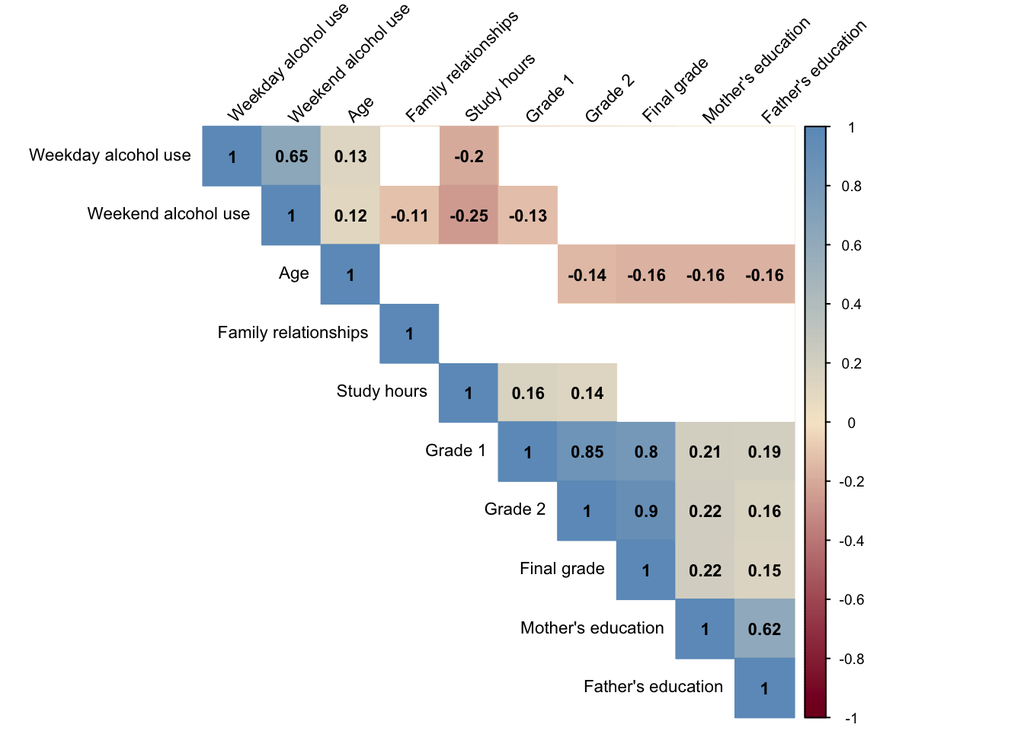

# Grades and student behaviour

In **Table 1** we saw that weekend and weekday alcohol consumption did not significantly differ between schools so we will explore the pooled data. In **Figure 1** only weekend alcohol use correlated with grades in the first period, however, grades throughout the academic year correlated together so we will explore each grade separately. Since we are interested in how grades are distributed across different levels of alcohol consumption we used `geom_boxplot()` to summarize this information. Outliers were calculated for each grade and plotted separately using `geom_jitter()` to better visualize how many outliers there are. Outliers are observations that fall beyond the interquartile range. **Figure 2** shows that grades follow a similar trend across the year, where students who drink less achieve higher grades and students who drink more achieve lower grades. Generally, the spread of grades across all levels of alcohol consumption is quite large as represented by the long whiskers. The spread does decrease as alcohol intake increases and the spread is greatest for final grades. Grades in the second period and the final grades show some evidence of positive skew at higher levels of alcohol consumption (i.e., the median is closer to the lower end of the IQR and the whisker is short). A number of students achieve zero grades even at very low levels of alcohol consumption, represented by the outliers plotted in red. While we would expect such outliers at high levels of alcohol consumption it is not immediately clear why students who drink less are receiving very low grades. One possibility is that these zero grades actually represent missing data - but it is impossible to tell and so we continue to treat them as observed scores.

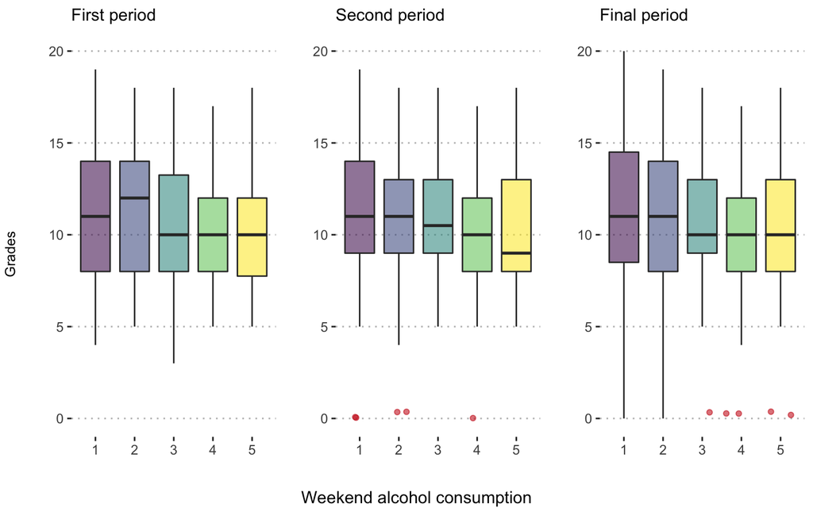

Time spent studying has a very obvious link to academic outcomes. Students who study for longer are more likely to perform better in exams. In **Table 1**, there are significant differences between schools regarding the number of hours students spend studying. We decided to visualise this information in a scatterplot using `geom_jitter()` and `geom_smooth()`. We were also interested in how many students fall into each category of study time (1 - 4 hours) and if this is different between schools, so we created a barplot using `geom_bar()` to visualise this. In **Figure 3** we see that grades generally increase as students spend more time studying. This trend is much steeper for students at MS, perhaps indicating that they require more effort to achieve high grades than students at GS. Notably, there are no students at MP that study more than 3 hours. This could also explain why grades are generally lower at MP and why we observe signficant differences between schools in **Table 1**. Again, the standard error of the slope is much greater for MP indicating these estimates are less realiable.

**Figure 3. Association between student grades in mathematics and hours spent studying each week**

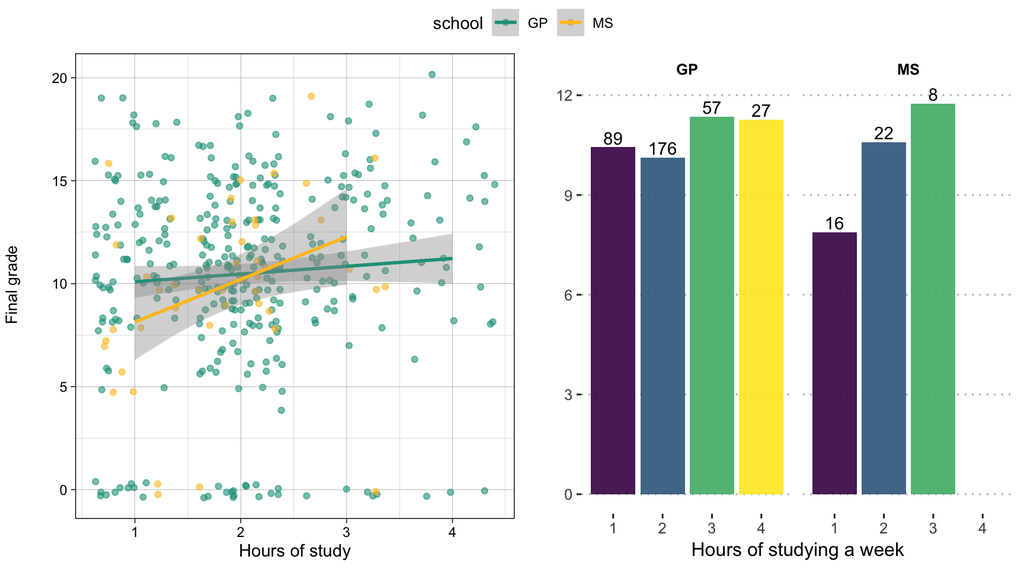

# Grades and socio-demographic factors

Socio-demographic factors are a broad range of characteristics relating to an individual and their household. Here we focus on age, mother’s education, quality of family relationships, and internet access. In **Table 1** we saw that age, mother’s education, and internet access differed significantly between the schools, so we decided to visualise this information per school. In **Figure 1** we also see weak, but significant correlations between these variables and grades. Although the quality of family relationships did not differ significantly between schools or correlate with grades, we firmly believe that this can have a strong effect on grades and decided to visualise this too. Age, mother’s education, and family relationships were visualised in a scatterplot using `geom_jitter()` and `geom_smooth()`, which fit a linear regression line to the data. School was mapped to the `colour` aesthetic to check for differences. In **Figure 4** we see that age is negatively associated with grades, such that older student’s achieve lower grades. The trend is similar for the two schools, but the spread of the data shows that students at MP are older than students at GS. This could be why grades are lower at MP. Mother’s education is positively associated with grades in GS and MP, suggesting that better educated mothers are able to help their children achieve better grades. Lastly, the association between grades and the quality of family relationships differs between schools. Students at GS see a positive trend, whereas students at MP see a negative trend. The majorty of students at both schools rate the quality of relationships highly, but the sample size is so much smaller at MP that students who give low ratings could be driving the negative association. Indeed, the standard error for the slope is much greater for students at MP compared to GS, suggesting the estimation is less reliable.

**Figure 4. Association between final grade in mathematics with age, mother’s education, and family relationships**

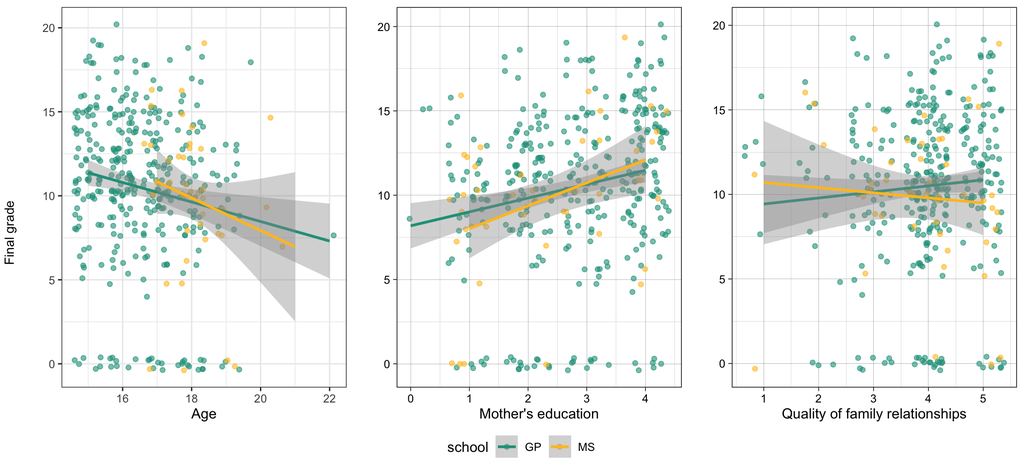

Internet access at home is an important resource for self-study and so could effect grades throughout the year. In **Table 1** we saw significant differences between schools in terms of internet access. We are interested if the average grade differs between schools according to internet access at home, and visualised this using `geom_line()` and `geom_errorbar()`. In **Figure 5** we see differencs in the mean grade with error bars that represent the standard error of the mean. The trend is similar in both schools, showing that students who have internet access at home achieve higher average grades. We also see that students at MP achieve lower average grades than GS (but again note the large error bars). **Table 1** shows that 30% of students at MP do not have internet access, compared to 15% of students at GS. This could also explain why grades are lower at MP.

**Figure 5. Association between internet access and average grade per school**

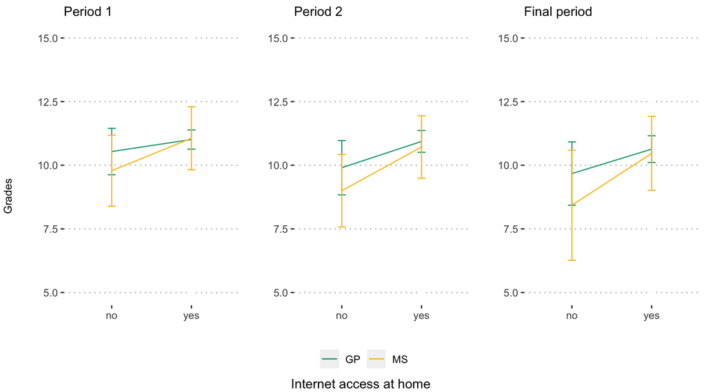

# Conclusion

Our goal was use visualisation to determine if alcohol consumption has an effect on mathematics grades in two schools. **Figure 2** does indicate that students who drink more get lower grades. We also discovered that additional factors are just as influential on grades, such as age, mother’s education, and hours spent studying. This indicates that grades are only partly explained by student lifestyle and behaviours (alcohol use, study effort) and that factors beyond a student’s control are also important (education of the mother, internet access). If a school is interested in boosting student’s grades, they should consider programs of targeted support (tutoring, financial) as well as motivating the student to engage in self-study and make positive lifestyle changes. The findings are exploratory and not causal and must be considered with care due to the imbalance in sample size between schools.